# Living Well Service users - EDA and Cluster Analysis

Nujcharee Haswell

7 February 2018

# Data Science Accelerator

author: Nujcharee Haswell date: 08/02/2018 autosize: true

# About Living Well Service

- Living Well North Yorkshire is a service which aims to support individuals in making changes to their lives. It forms part of the council’s wider prevention programme.
- The service offers Living Well Co-ordinators, who work with individuals including carers who may be on the cusp of needing formal care, by visiting their homes on a one-to-one basis.
- Our aims are to work with individuals to help them identify solutions to address their health and wellbeing goals and maximise period of indepedence.

# Challenges

Over 4,000 contacts made since 2015. Everyone is offered access to services if they havent already received formal social care or havent known to the social care assessments / reviews process.

- Identify characteristics of service users who likely will benefit most from the service (consequently do not require social care pathway, periods of independence is maximised)
- Identify the likihood whether they are to return for social care services within the next 12 months.

# How we are going about to achieve this

Apply Machine Learning techniques:

- Unsupervised Machine Learning -> KMeans Cluster Analysis
- Supervised Machine Learning -> General Linear Regression (GLM) for binary classification

# Data preparation

To achieve the above objectives, my initial thoughts were to follow below approaches. I use R for this project:

- Unsupervised Machine Learning -> KMeans Cluster Analysis
- Supervised Machine Learning -> General Linear Regression (GLM) for binary classification

Exploring data

```r
library(tidyverse)
library(readr)
suppressWarnings(library(ggplot2))

lwa <- read.csv("C:/viz/Accelerator/data/train.csv", stringsAsFactor = FALSE, na.strings =  c("null", ""))

lwa$PersonID = NULL

lwa = lwa[,1:10]
head(lwa)
```

```
##   GENDER_DESCRIPTION ETHNICITY_DESCRIPTION  RELIGION_DESCRIPTION
## 1             Female  A1 - White - British The Church Of England
## 2             Female  A1 - White - British            Not Stated
## 3             Female  A1 - White - British                  <NA>
## 4             Female  A1 - White - British The Church Of England
## 5             Female  A1 - White - British The Church Of England
## 6             Female  A1 - White - British      Methodist Church
##   MARSTAT_DESCRIPTION SEX_ORIENT_DESC ELIG_CTGRY_DESC ACC_LIVES_ALONE_FLAG
## 1             Widowed            <NA>            <NA>                    Y
## 2             Married            <NA>            <NA>                    N
## 3              Single            <NA>            <NA>                    N
## 4             Married            <NA>            <NA>                    Y
## 5                <NA>            <NA>            <NA>                    Y
## 6              Single            <NA>            <NA>                    N
##   DIM_LOOKUP_TENURE_CODES_DESC     DIM_LOOKUP_ACCOM_CODES_DESC AgeToday
## 1                         <NA> Semi-Detached House or Bungalow       94
## 2                Owns Property      Detached House Or Bungalow       64
## 3                         <NA>                            <NA>       41
## 4                         <NA>               Sheltered Housing       68
## 5                Social Rented               Sheltered Housing       58
## 6                         <NA>                            <NA>       53
```

```r
##find number of records
dim(lwa)
```

```
## [1] 1000   10
```

```r
##1,000 random sample records are loaded into the workspace with 58 columns

train <- read.csv("C:/viz/Accelerator/data/Book2.csv", stringsAsFactor = FALSE, na.strings =  c("null", ""))
```

# Dealing with missing data

```r
train$PersonID = NULL
Missing_indices <- sapply(train,function(x)sum(is.na(x)))
Missing_Summary <- data.frame(index = names(train),Missing_Values=Missing_indices)
Missing_Summary[Missing_Summary$Missing_Values > 0,]
```

```
##                                                                     index
## ACC_LIVES_ALONE_FLAG                                 ACC_LIVES_ALONE_FLAG
## IMDScore                                                         IMDScore
## LSOA.code                                                       LSOA.code
## LSOA.Name                                                       LSOA.Name
## Index.of.Multiple.Deprivation.Decile Index.of.Multiple.Deprivation.Decile
## Income.Decile                                               Income.Decile
## Employment.Decile                                       Employment.Decile
## Education.and.Skills.Decile                   Education.and.Skills.Decile
## Health.and.Disability.Decile                 Health.and.Disability.Decile
## Crime.Decile                                                 Crime.Decile
## Living.Environment.Decile                       Living.Environment.Decile
##                                      Missing_Values
## ACC_LIVES_ALONE_FLAG                              5
## IMDScore                                         35
## LSOA.code                                       449
## LSOA.Name                                       449
## Index.of.Multiple.Deprivation.Decile            449
## Income.Decile                                   449
## Employment.Decile                               449
## Education.and.Skills.Decile                     449
## Health.and.Disability.Decile                    449
## Crime.Decile                                    449
## Living.Environment.Decile                       449
```

```r
Missing_m = data.matrix(Missing_Summary)
Missing_m
```

```
##                                                                     index
## ACC_LIVES_ALONE_FLAG                                                    5
## AgeToday                                                                6
## IMDScore                                                               44
## SA_ALERT                                                               76
## Mobility                                                               61
## LD                                                                     52
## Support.to.Carer                                                       88
## Personal.Care.Support                                                  70
## Mental.Health.Support                                                  60
## Substance.Misuse                                                       87
## Social.Isolation                                                       85
## Support.with.Memory.and.Cognition                                      89
## Hearing.Impairment                                                     41
## Visual.Impairment                                                      91
## Dual.Impairment                                                        22
## Asylum.Seeker.Support                                                   7
## Internal                                                               49
## Self                                                                   79
## Other                                                                  64
## Health...GP                                                            37
## Internal.Dept..HAS.                                                    51
## Voluntary.Agency                                                       92
## Secondary.Health.Professional..Eg..Hospital.Consultant..Ward..Etc..    78
## Care.Co.Ordinator                                                      14
## Health...Mental.Health.Worker                                          38
## Family                                                                 29
## Housing.Association                                                    43
## Independent.Sector.Provider                                            47
## Health...Other.Primary.Health.Professional                             39
## Health...Community.Nurse                                               36
## District.Council.Housing                                               20
## Other.Local.Authority                                                  66
## Emergency.Service...Police                                             25
## Same.La...Other.Directorate                                            77
## Internal.Dept..CYPS.                                                   50
## Friend                                                                 35
## Neighbour                                                              62
## Legal.Agency..Court..Probation.                                        53
## Independent.Sector..Community.                                         46
```

[output cut: 135 more lines]

```
## Bed.and.Breakfast                                                                0
## B4...Mixed...Any.Other.Mixed.Background                                          0
## Emergency.Accommodation                                                          0
## A3...White...Traveller.of.Irish.Heritage                                         0
## F3...Refused                                                                     0
## POSTCODE                                                                         0
## LSOA.code                                                                      449
## LSOA.Name                                                                      449
## Index.of.Multiple.Deprivation.Decile                                           449
## Income.Decile                                                                  449
## Employment.Decile                                                              449
## Education.and.Skills.Decile                                                    449
## Health.and.Disability.Decile                                                   449
## Crime.Decile                                                                   449
## Living.Environment.Decile                                                      449
```

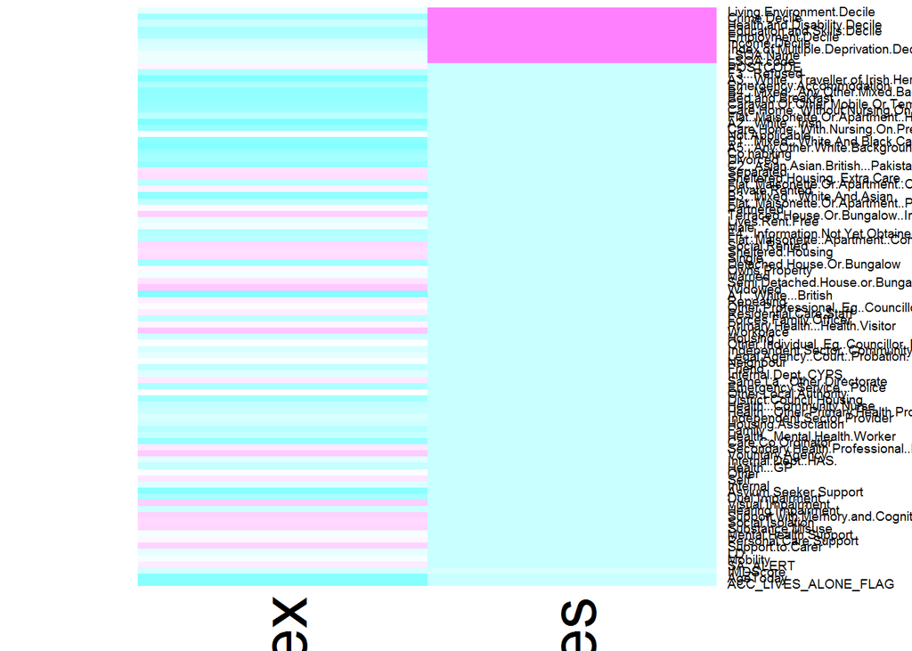

```r
missing_heatmap <-  heatmap(Missing_m, Rowv=NA, Colv=NA, col = cm.colors(256), scale="column", margins=c(3,3))
```

As demonstrated in the heatmap, there are a number of columns that contain missing values. I got a couple of approaches to tackle

- Approach #1 -> Remove records
- Approach #2 -> Imputation technique application called “Label encoding” which is simply converting each value in a column to a number.

# Feature Selections

Visualising Data - To compare between two groups - Repeating Service Users / Non - Repeating

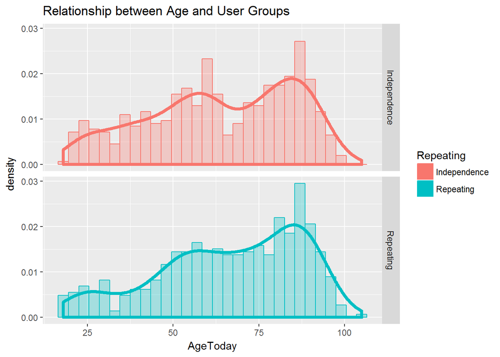

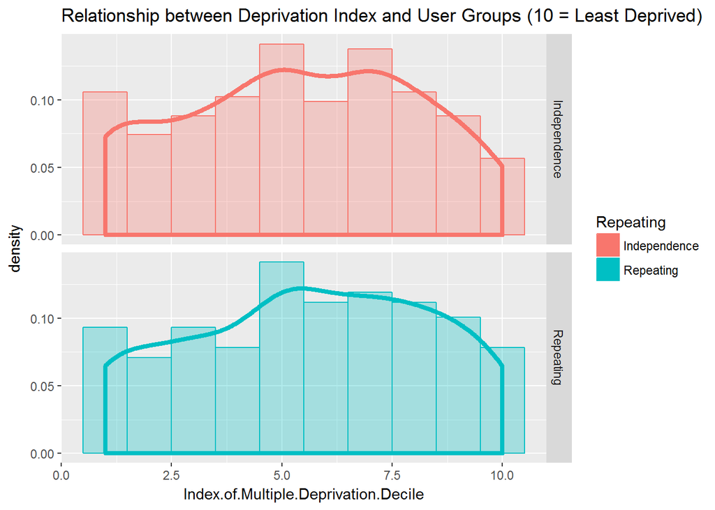

## Decision Tree with RPart package

Since there are 50+ variables and this is a classification problem, I look for a technique that helps me explore data visually.

```r
library(rpart)
library(rpart.plot)
library(caret)
library(visNetwork)

ints <- sapply(train, is.integer)
intsCols <- names(train[, ints])


# data = train
#
# data[intsCols] = gsub(0,"No",data[intsCols])
# data[intsCols] = gsub(1,"Yes",data[intsCols])

##data %>% mutate_at(intsCols, funs(factor(.)))



tree = rpart(Repeating ~. - AgeToday, data = train, method = "class")
summary(tree)
```

```
## Call:
## rpart(formula = Repeating ~ . - AgeToday, data = train, method = "class")
##   n= 1000
##
##           CP nsplit rel error   xerror       xstd
## 1 0.02886598      0 1.0000000 1.000000 0.03258613
## 2 0.02680412      1 0.9711340 1.107216 0.03251142
## 3 0.02474227      2 0.9443299 1.103093 0.03252083
## 4 0.01443299      3 0.9195876 1.090722 0.03254592
## 5 0.01134021      4 0.9051546 1.068041 0.03257967
## 6 0.01099656      6 0.8824742 1.084536 0.03255669
## 7 0.01030928     11 0.8247423 1.084536 0.03255669
## 8 0.01000000     12 0.8144330 1.082474 0.03256002
##
## Variable importance
##                                                             Married
##                                                                  16
##                                                             Widowed
##                                                                  13
## Secondary.Health.Professional..Eg..Hospital.Consultant..Ward..Etc..
##                                                                   8
##                                                              Single
##                                                                   8
##                                                   Care.Co.Ordinator
##                                                                   7
##                                                    Social.Isolation
##                                                                   7
##                                     Semi.Detached.House.or.Bungalow
##                                                                   6
##                                                            Divorced
##                                                                   6
##                                                         Health...GP
##                                                                   5
##                       Terraced.House.Or.Bungalow..Inc..End.Terrace.
##                                                                   5
##                                                       Owns.Property
##                                                                   5
##             Flat..Maisonette..Apartment..Converted.Or.Shared.House.
##                                                                   5
##                                                ACC_LIVES_ALONE_FLAG
```

[output cut: 224 more lines]

```
##
## Node number 137: 30 observations
##   predicted class=Repeating     expected loss=0.4  P(node) =0.03
##     class counts:    12    18
##    probabilities: 0.400 0.600
##
## Node number 272: 525 observations
##   predicted class=Independence  expected loss=0.4190476  P(node) =0.525
##     class counts:   305   220
##    probabilities: 0.581 0.419
##
## Node number 273: 27 observations
##   predicted class=Repeating     expected loss=0.4074074  P(node) =0.027
##     class counts:    11    16
##    probabilities: 0.407 0.593
```

```r
##Explore variable importance using Caret
varImp(tree)
```

```
##                                                                        Overall
## A1...White...British                                                 4.6352485
## A5...Any.Other.White.Background                                      1.1374907
## ACC_LIVES_ALONE_FLAG                                                 3.0579775
## Care.Co.Ordinator                                                    5.3728747
## Divorced                                                             3.5719629
## Flat..Maisonette..Apartment..Converted.Or.Shared.House.             13.0438342
## Health...Community.Nurse                                             0.8814254
## Health...GP                                                          4.3776316
## Health...Other.Primary.Health.Professional                           1.7853058
## Internal                                                             1.8534279
## Internal.Dept..HAS.                                                  1.2344775
## Male                                                                11.1600805
## Married                                                              5.1200262
## Owns.Property                                                        7.0938950
## Personal.Care.Support                                                1.1059720
## SA_ALERT                                                             0.6394737
## Secondary.Health.Professional..Eg..Hospital.Consultant..Ward..Etc..  2.3121963
## Semi.Detached.House.or.Bungalow                                      2.0151673
## Single                                                               2.3659940
## Social.Isolation                                                     2.2672560
## Social.Rented                                                        5.4003147
## Support.to.Carer                                                     0.5049597
## Terraced.House.Or.Bungalow..Inc..End.Terrace.                        1.6339976
## Widowed                                                              4.6273109
## Mobility                                                             0.0000000
## LD                                                                   0.0000000
## Mental.Health.Support                                                0.0000000
## Substance.Misuse                                                     0.0000000
## Support.with.Memory.and.Cognition                                    0.0000000
## Hearing.Impairment                                                   0.0000000
## Visual.Impairment                                                    0.0000000
## Dual.Impairment                                                      0.0000000
## Asylum.Seeker.Support                                                0.0000000
## Self                                                                 0.0000000
## Other                                                                0.0000000
## Voluntary.Agency                                                     0.0000000
## Health...Mental.Health.Worker                                        0.0000000
## Family                                                               0.0000000
## Housing.Association                                                  0.0000000
```

[output cut: 27 more lines]

```
## Separated                                                            0.0000000
## C2...Asian.Asian.British...Pakistani                                 0.0000000
## Co.habiting                                                          0.0000000
## B1...Mixed...White.And.Black.Caribbean                               0.0000000
## Not.Applicable                                                       0.0000000
## Care.Home..With.Nursing.On.Premises.                                 0.0000000
## A2...White...Irish                                                   0.0000000
## Flat..Maisonette.Or.Apartment..High.Rise.Apartment.                  0.0000000
## Care.Home..Without.Nursing.On.Premises.                              0.0000000
## Caravan.Or.Other.Mobile.Or.Temporary.Structure                       0.0000000
## Bed.and.Breakfast                                                    0.0000000
## B4...Mixed...Any.Other.Mixed.Background                              0.0000000
## Emergency.Accommodation                                              0.0000000
## A3...White...Traveller.of.Irish.Heritage                             0.0000000
## F3...Refused                                                         0.0000000
```

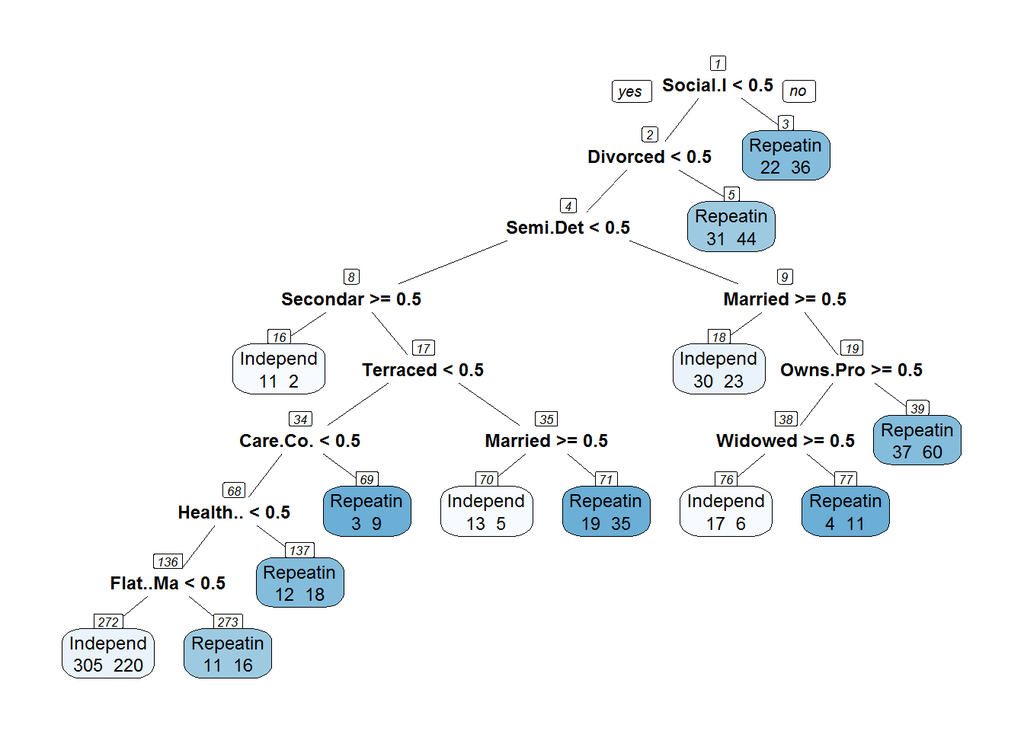

```r
prp(tree, extra=1, faclen=0,  nn=T, box.palette="Blues")
```

```r
visTree(tree, main = "Living Well Service Users Tree", width = "100%")
```

[interactive chart not shown]

## Decision tree Pros & Cons

Advantages - Simple to understand, interpret, visualise (small) - Can handle both numerical and categorical features - Can handle missing data (automatically) - Robust to outliers - Require little data preparationa

Disadvantage

- Large trees can be hard to interpret
- Trees have high variance, which causes model to performance to be poor
- Trees overfit easily

## Lessons Learned + Next steps

- Spend more time understanding the data e.g format of data, is it appropriate for this analysis
- Is the data at the right granuarity? Person Level, Contact Level
- Revise ethnical framework by GDS
- Focused!!!

Next step -> explore predictive modelling

## More about RPart

http://oldemarrodriguez.com/yahoo_site_admin/assets/docs/Ploting_a_Tree_with_prp.234140400.pdf

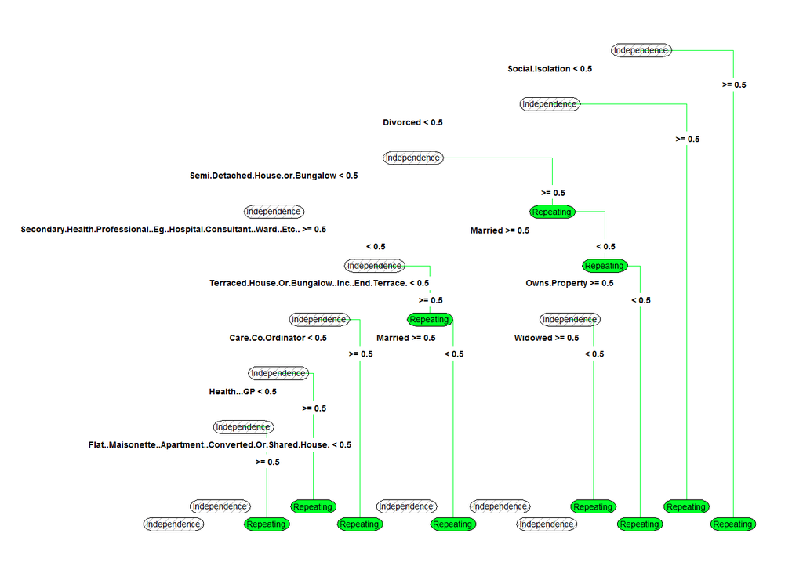